# Troubleshooting guide

Author

PHAC-RUG

## Summer of R Basics - Office hours

Topics we covered through this learning series:

- Intro to R and the tidyverse
- ggplot2 for data viz
- Data cleaning using janitor and the tidyverse

## Troubleshooting tips

When stuck, do not despair! Chances are that someone else has run into the same issue before. Here are some practical steps to try and troubleshoot before reaching out for help:

### 1. Check R and your Environment

Before diving deep, make sure your setup is working as expected:

- **Is R itself up to date?**
  - Run `R.version.string` to check.
  - Updating to the latest release can fix known bugs.
- **Is RStudio (or your IDE) up to date?**
  - RStudio regularly patches bugs and adds features that affect package handling and rendering.
- **Are your packages installed?**
  - Use `installed.packages()` or try `library(packagename)` to confirm.
  - If missing, install with `install.packages("packagename")`.
- **Are your packages loaded?**
  - Just installing a package isn’t enough — you need to load it from your library
    - `library(packagename)` at the top of your script or chunk.
- **Check for warnings when loading packages.**
  - Warnings may indicate version conflicts, missing dependencies, or that an update is required.
- **Are packages up to date?**
  - Run `old.packages()` to see what’s outdated
  - Update with `update.packages(ask = FALSE)` or point and click “Update” in the Packages tab
- **Check conflicts between packages.**
  - If two packages have functions with the same name, R will use the one loaded last.
  - Use `conflicted::conflict_scout()` to identify overlaps.
- **Check your working directory.**
  - Run `getwd()` to see where R is looking for files.
  - Use `setwd()` or the [`here`](https://cran.r-project.org/web/packages/here/vignettes/here.html) package
  - If your code can’t find a file, it might just be looking in the wrong place.
- **Restart your R session.**
  - Sometimes lingering objects or masked functions cause strange errors.
  - In RStudio: Session → Restart R or press `Ctrl + Shift + F10`.

### 2. Read the Function Manual

- Use ?function_name or help(function_name) to pull up documentation.

```r
# help for packages
?tidyverse
```

```
starting httpd help server ... done
```

```r
# help for functions
?mutate
```

- Check the Examples section at the bottom of help pages — often the quickest way to see correct usage.
- Try example(function_name) to run a few built-in demos.

**Note**

example() only works with packages that provided examples of use**

```r
example(summary)
```

```
summry> summary(attenu, digits = 4) #-> summary.data.frame(...), default precision
     event            mag           station         dist
 Min.   : 1.00   Min.   :5.000   117    :  5   Min.   :  0.50
 1st Qu.: 9.00   1st Qu.:5.300   1028   :  4   1st Qu.: 11.32
 Median :18.00   Median :6.100   113    :  4   Median : 23.40
 Mean   :14.74   Mean   :6.084   112    :  3   Mean   : 45.60
 3rd Qu.:20.00   3rd Qu.:6.600   135    :  3   3rd Qu.: 47.55
 Max.   :23.00   Max.   :7.700   (Other):147   Max.   :370.00
                                 NA's   : 16
     accel
 Min.   :0.00300
 1st Qu.:0.04425
 Median :0.11300
 Mean   :0.15422
 3rd Qu.:0.21925
 Max.   :0.81000


summry> summary(attenu $ station, maxsum = 20) #-> summary.factor(...)
    117    1028     113     112     135     475    1030    1083    1093    1095
      5       4       4       3       3       3       2       2       2       2
    111     116    1219    1299     130    1308    1377    1383 (Other)    NA's
      2       2       2       2       2       2       2       2     120      16

summry> lst <- unclass(attenu$station) > 20 # logical with NAs

summry> ## summary.default() for logicals -- different from *.factor:
summry> summary(lst)
   Mode   FALSE    TRUE    NA's
logical      28     138      16

summry> summary(as.factor(lst))
FALSE  TRUE  NA's
   28   138    16
```

### 3. Look for Clues in Error Messages

- Don’t ignore error messages — read them carefully.

```r
df <- data.frame(
  id = 1:3,
  age = c("25", "thirty", "40"))

# try to convert age to numeric
df$age_num <- as.numeric(df$age)
```

[output not shown]

- Break them down: they usually tell you what object is missing, what type is expected, or where the code broke.
  - In this example, R couldn’t turn some of the values into numbers
  - Inspect the data, in this case “thirty” would need to be converted to 30
- If the message is unclear, copy the exact text into a search engine or Stack Overflow.

```r
df2 <- data.frame(
  site = c("A", "B", "C"),
  var1 = c(1, 2, 3),
  var2 = c(4, 5, 6))

# Try to standardize multiple columns
df2 %>%
  mutate(across(var1, var2, as.numeric()))
```

```
Error in `mutate()`:
ℹ In argument: `across(var1, var2, as.numeric())`.
Caused by error:
! object 'var2' not found
```

In this example we can search something like: “mutate across columns as.numeric”

- The AI summary has a suggested fix we can try, or we can click through the links to find a solution

[figure not shown]

Fig 1. Google search results

```r
df2 %>%
  mutate(across(c(var1, var2), as.numeric))
```

```
  site var1 var2
1    A    1    4
2    B    2    5
3    C    3    6
```

[figure not shown]

Fig 2. Google search results, additional options

### 4. Simplify the Problem

- Reproduce the issue with the smallest possible piece of code (a “minimal reproducible example”).
- Run the code incrementally, execute line by line or in small chunks
- This often reveals the problem right away. If not, it makes it easier for others to help you.

### 5. Search Before You Ask

- Google or search Stack Overflow.
- Include “R” + function name + error message in your search (see example above)
- R has been around a long time — many issues already have answers online.

### 6. Leverage R Resources

- [RStudio Community](https://forum.posit.co/)
- CRAN package vignettes (vignette(“packagename”))
- Cheatsheets from Posit (R Cheatsheets)

### 7. Asking for Help (Last Step)

If you’ve tried the above and still need help:

- Provide a clear description of the problem.
- Include code or example code with the issue.
- Mention what you’ve already tried.

Another option:

- using AI
  - https://claude.ai/

**Warning**

Be mindful of AI tools, they can hallucinate and produce responses that are not useful. Do not include sensitive information in your queries.

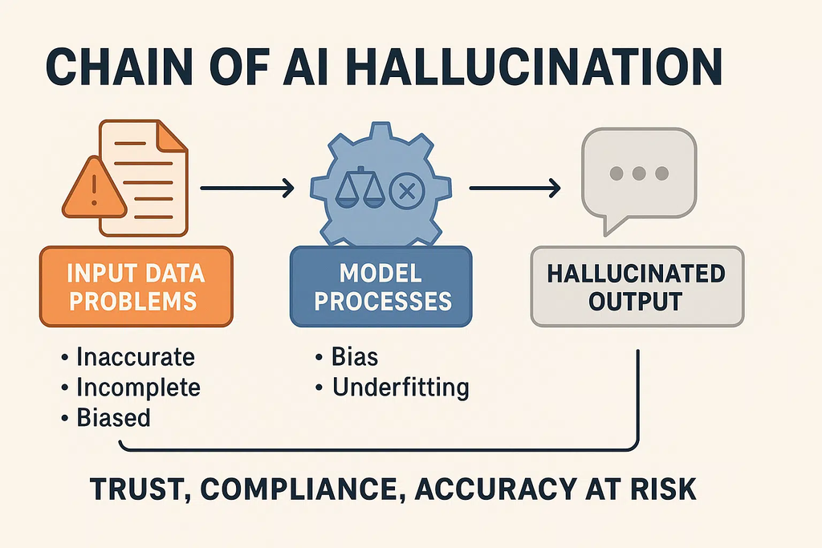

[Image source](https://shelf.io/blog/garbage-in-garbage-out-ai-implementation/)

Asking for help on online forums:

https://stackoverflow.com/help/how-to-ask

## Troubleshooting resources

[A Beginner’s Guide to Troubleshooting R Code](https://bioinformatics.ccr.cancer.gov/docs/btep-coding-club/CC2023/Troubleshooting_Rprog/)

[Troubleshooting Error Messages](https://bookdown.org/yih_huynh/Guide-to-R-Book/trouble.html)

[Troubleshooting in R](https://ecorepsci.github.io/reproducible-science/troubleshooting.html)

[TROUBLESHOOTING AND HOW TO FIND HELP](https://ourcodingclub.github.io/tutorials/troubleshooting/)

[Debugging](https://adv-r.hadley.nz/debugging.html)

## Courses

### Paid, with certificates

[R for PH/epi](https://appliedepi.org/training/training.html)

[R for Data science](https://www.edx.org/certificates/professional-certificate/harvardx-data-science)

### Free, with option for paid certificate

[Learn R](https://www.codecademy.com/learn/learn-r)